# Regression

2024-11-17

```r
library(readxl)
library(forecast)
```

```r
library(tseries)
library(TTR)
library(ggplot2)
library(tidyr)
library(dplyr)
Inflation_Data <- read_excel("~/Downloads/CPI - Dataset No Description.xlsx")
GDP_Data <- read.csv("~/Downloads/GDPC1.csv")
```

```r
library(lubridate)
GDP_Data$DATE <- as.Date(GDP_Data$DATE)
GDP_Data$Year <- year(GDP_Data$DATE)
```

```r
Annual_GDP <- GDP_Data %>%
  group_by(Year) %>%
  summarize(Avg_GDP = mean(GDPC1, na.rm = TRUE))
```

```r
Annual_GDP <- Annual_GDP %>%
  mutate(GDP_Growth_Rate = (Avg_GDP - lag(Avg_GDP)) / lag(Avg_GDP) * 100) %>%
  filter(!is.na(GDP_Growth_Rate))
```

```r
Inflation_Data <- Inflation_Data %>%
  mutate(Annual_Inflation = rowMeans(select(., Jan:Dec), na.rm = TRUE))
```

```r
merged_data <- merge(select(Inflation_Data, Year, Annual_Inflation), Annual_GDP, by = "Year")
```

```r
model <- lm(Annual_Inflation ~ GDP_Growth_Rate, data = merged_data)
summary(model)
```

```
##
## Call:
## lm(formula = Annual_Inflation ~ GDP_Growth_Rate, data = merged_data)
##
## Residuals:
##     Min      1Q  Median      3Q     Max
## -27.945 -21.046  -8.698  15.415  48.683
##
## Coefficients:
##                 Estimate Std. Error t value Pr(>|t|)
## (Intercept)      260.026     14.728  17.655 2.72e-08 ***
## GDP_Growth_Rate    1.676      4.842   0.346    0.737
## ---
## Signif. codes:  0 '***' 0.001 '**' 0.01 '*' 0.05 '.' 0.1 ' ' 1
##
## Residual standard error: 28.81 on 9 degrees of freedom
## Multiple R-squared:  0.01313,    Adjusted R-squared:  -0.09652
## F-statistic: 0.1198 on 1 and 9 DF,  p-value: 0.7372
```

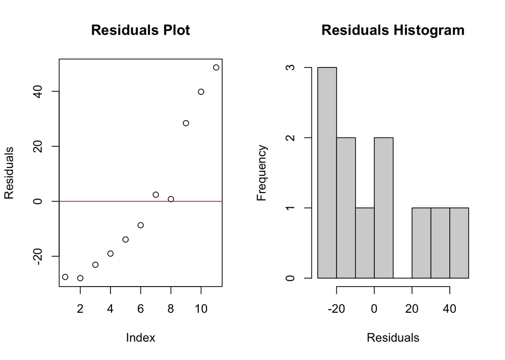

```r
par(mfrow=c(1,2))
plot(model$residuals, main="Residuals Plot", ylab="Residuals", xlab="Index")
abline(h=0, col="red")

hist(model$residuals, main="Residuals Histogram", xlab="Residuals", breaks=10)
```

Coefficient for GDP Growth Rate: 1.676 (p = 0.737), indicating no statistically significant impact on inflation.

R-squared: 0.013, showing that only 1.3% of the inflation variance is explained by GDP growth.

Adjusted R-squared: -0.097, suggesting a poor model fit.

F-statistic: 0.12 (p = 0.737), further confirms the model’s insignificance.

The residual analysis shows a pattern and skewed distribution, indicating issues with model assumptions. In summary, GDP growth rate alone is not an effective predictor of inflation in this model.

```r
FedFunds_Data <- read.csv("~/Downloads/FEDFUNDS.csv")
```

```r
FedFunds_Data$DATE <- as.Date(FedFunds_Data$DATE)
FedFunds_Data$Year <- year(FedFunds_Data$DATE)
```

```r
Annual_FedFunds <- FedFunds_Data %>%
  group_by(Year) %>%
  summarize(FedFunds_Rate = mean(FEDFUNDS, na.rm = TRUE))
```

```r
merged_data <- merged_data %>%
  inner_join(Annual_FedFunds, by = "Year")
```

```r
model_with_fedfunds <- lm(Annual_Inflation ~ GDP_Growth_Rate + FedFunds_Rate, data = merged_data)
summary(model_with_fedfunds)
```

```
##
## Call:
## lm(formula = Annual_Inflation ~ GDP_Growth_Rate + FedFunds_Rate,
##     data = merged_data)
##
## Residuals:
##     Min      1Q  Median      3Q     Max
## -15.912 -10.445  -8.465  10.029  27.921
##
## Coefficients:
##                 Estimate Std. Error t value Pr(>|t|)
## (Intercept)      241.718      9.776  24.725 7.65e-09 ***
## GDP_Growth_Rate    1.100      2.878   0.382  0.71219
## FedFunds_Rate     12.031      2.873   4.187  0.00305 **
## ---
## Signif. codes:  0 '***' 0.001 '**' 0.01 '*' 0.05 '.' 0.1 ' ' 1
##
## Residual standard error: 17.11 on 8 degrees of freedom
## Multiple R-squared:  0.6908, Adjusted R-squared:  0.6135
## F-statistic: 8.937 on 2 and 8 DF,  p-value: 0.009141
```

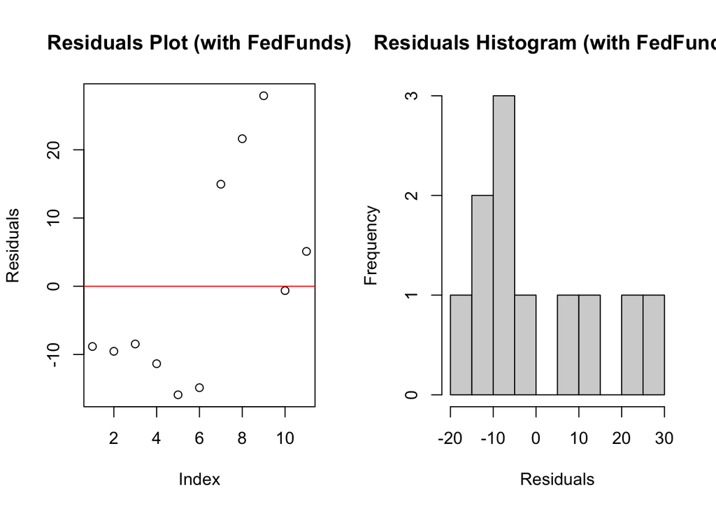

```r
par(mfrow = c(1, 2))
plot(model_with_fedfunds$residuals, main = "Residuals Plot (with FedFunds)", ylab = "Residuals", xlab = "Index")
abline(h = 0, col = "red")

hist(model_with_fedfunds$residuals, main = "Residuals Histogram (with FedFunds)", xlab = "Residuals", breaks = 10)
```

The model’s R-squared value of 0.6908 indicates that about 69% of the variance in inflation is explained by the model, demonstrating a strong fit. The adjusted R-squared, at 0.6135, confirms that the model remains a good fit even after accounting for the number of predictors. Additionally, the F-statistic of 8.937 with a p-value of 0.009 suggests that the overall model is significant, meaning that at lea the Federal Funds Rate has a meaningful impact on inflation.

In summary, the Federal Funds Rate is a better predictor of inflation than GDP growth rate, as it is statistically significant and improves the model’s explanatory power. Including the Federal Funds Rate in the model greatly enhances its ability to predict inflation, making it a more suitable independent variable for this analysis compared to GDP growth rate alone.